# DataProg Project

# Aggregation of data

### Count of each protein

```r
protCount <- covidData |>
  count(`Protein Name`) |>
  arrange(desc(n))

print(protCount)
```

```
# A tibble: 18 × 2
   `Protein Name`     n
   <chr>          <int>
 1 ORF1ab         10729
 2 ORF3a           5399
 3 N               5395
 4 ORF8            5389
 5 M               5388
 6 S               5386
 7 E               5385
 8 ORF10           5379
 9 ORF6            5362
10 ORF7a           5359
11 ORF7b           5297
12 orf1ab            47
13 ORF1a              1
14 orf10              1
15 orf3a              1
16 orf6               1
17 orf7a              1
18 orf8               1
```

### Average length of protein sequences

```r
avgProtLength <- covidData |>
  mutate(ProteinLength = str_length(`Protein Sequence`)) |>
  summarise(AverageLength = mean(ProteinLength, na.rm = TRUE)) |>
  as.numeric()

print(avgProtLength)
```

```
[1] 1173.188
```

### Submission dates frequency

```r
#Convert the Submission Date column to Date format using lubridate
covidData <- covidData |>
  mutate(`Submission Date` = dmy(`Submission Date`))

subDates <- covidData |>
  count(`Submission Date`) |>
  arrange(desc(n))

print(subDates)
```

```
# A tibble: 98 × 2
   `Submission Date`     n
   <date>            <int>
 1 2020-09-04        39516
 2 2020-04-23         1848
 3 2020-05-08         1571
 4 2020-09-03         1284
 5 2020-05-11         1266
 6 2020-04-13         1249
 7 2020-08-04         1160
 8 2020-08-06         1140
 9 2020-04-24         1127
10 2020-05-26         1092
# ℹ 88 more rows
```

### Number of unique Nuccore ids per protein name

```r
uniqueNuccId <- covidData |>
  group_by(`Protein Name`) |>
  summarise(uniqueNuccId = n_distinct(`Nuccore ids`)) |>
  arrange(desc(uniqueNuccId))

print(uniqueNuccId)
```

```
# A tibble: 18 × 2
   `Protein Name` uniqueNuccId
   <chr>                 <int>
 1 ORF3a                  5399
 2 N                      5395
 3 ORF8                   5389
 4 M                      5388
 5 S                      5386
 6 E                      5385
 7 ORF10                  5379
 8 ORF1ab                 5377
 9 ORF6                   5362
10 ORF7a                  5359
11 ORF7b                  5297
12 orf1ab                   47
13 ORF1a                     1
14 orf10                     1
15 orf3a                     1
16 orf6                      1
17 orf7a                     1
18 orf8                      1
```

# Exploratory data analysis

### Bar plot for the count of each protein

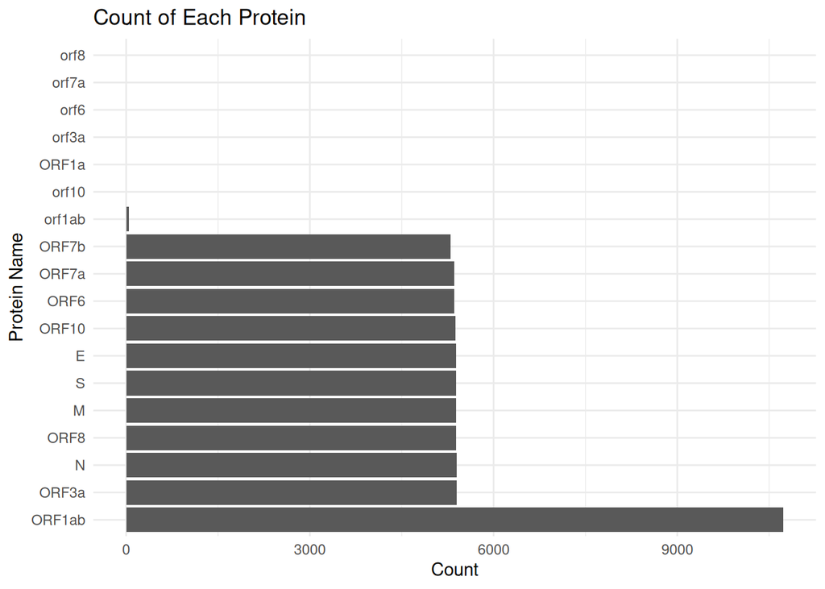

```r
library(ggplot2)

ggplot(protCount, aes(x = reorder(`Protein Name`, -n), y = n)) +
  geom_bar(stat = "identity") +
  coord_flip() +
  labs(title = "Count of Each Protein", x = "Protein Name", y = "Count") +
  theme_minimal()
```

#### According to this plot, we can see that the most submitted sample is the *ORF1ab* protein.

### Histogram of the number of submissions over time

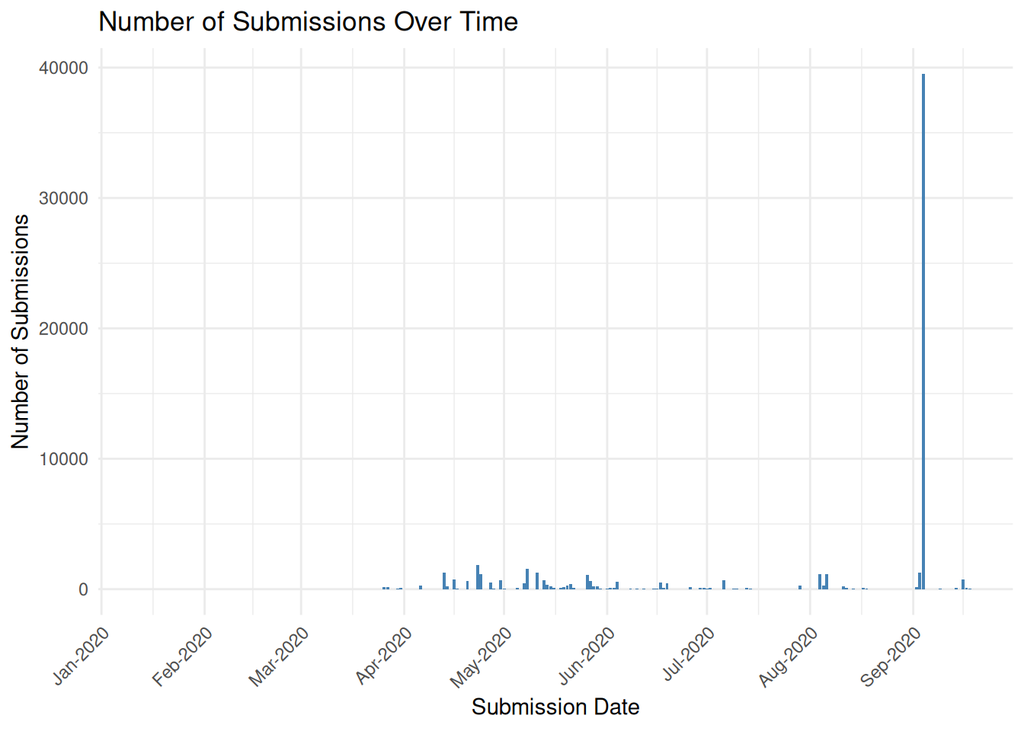

```r
ggplot(subDates, aes(x = `Submission Date`, y = n)) +
  geom_col(fill = "steelblue") +
  scale_x_date(date_labels = "%b-%Y", date_breaks = "1 month") +
  labs(title = "Number of Submissions Over Time", x = "Submission Date", y = "Number of Submissions") +
  theme_minimal() +
  theme(axis.text.x = element_text(angle = 45, hjust = 1))
```

#### This histogram clearly shows an absolutely astonishing jump in number of submissions of COVID-19 protein samples in september of 2020, most likely indicating a break-through in the research!

#### Based on this new knowledge I decided to figure out which protein was the most submitted in september 2020 to realize which protein was part of the breakthrough. Is it the previously mentioned *ORF1ab*?

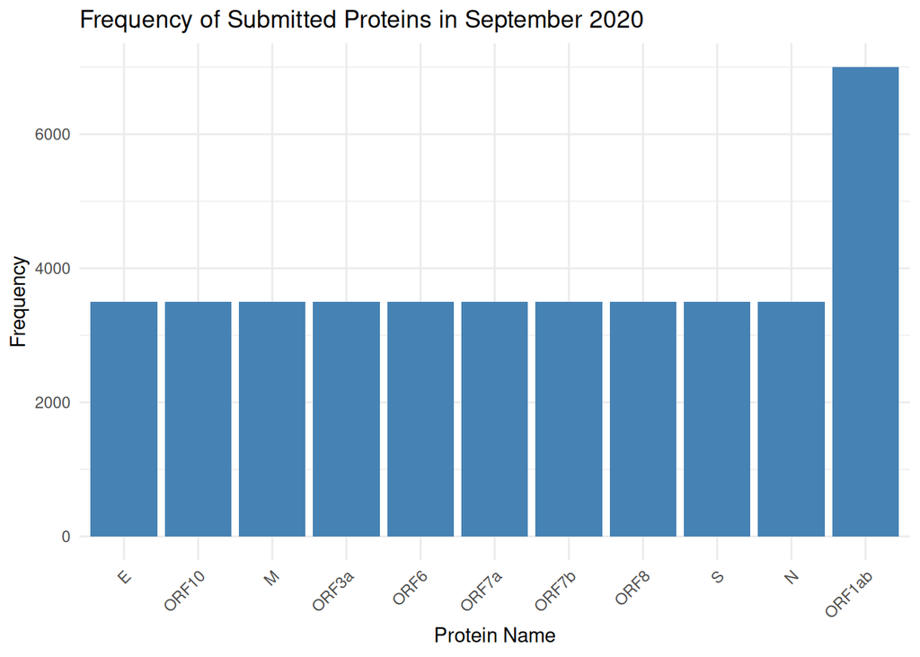

```r
# Filter the data for September 2020 submissions
septSubs <- covidData |>
  filter(`Submission Date` >= as.Date("2020-09-01") &
         `Submission Date` <= as.Date("2020-09-30"))

# Count the frequency of each protein
protFreq <- table(septSubs$`Protein Name`)
protFreqdf <- as.data.frame(protFreq)
names(protFreqdf) <- c("Protein Name", "Frequency")

# Sort the data frame by frequency in descending order
protFreqdf <- protFreqdf[order(-protFreqdf$Frequency), ]

# Plot
ggplot(protFreqdf, aes(x = reorder(`Protein Name`, Frequency), y = Frequency)) +
  geom_bar(stat = "identity", fill = "steelblue") +
  labs(title = "Frequency of Submitted Proteins in September 2020",
       x = "Protein Name",
       y = "Frequency") +
  theme_minimal() +
  theme(axis.text.x = element_text(angle = 45, hjust = 1))
```

### Making a genemap using gggenes that shows how all the proteins were positioned in the genome (Hypothetical).

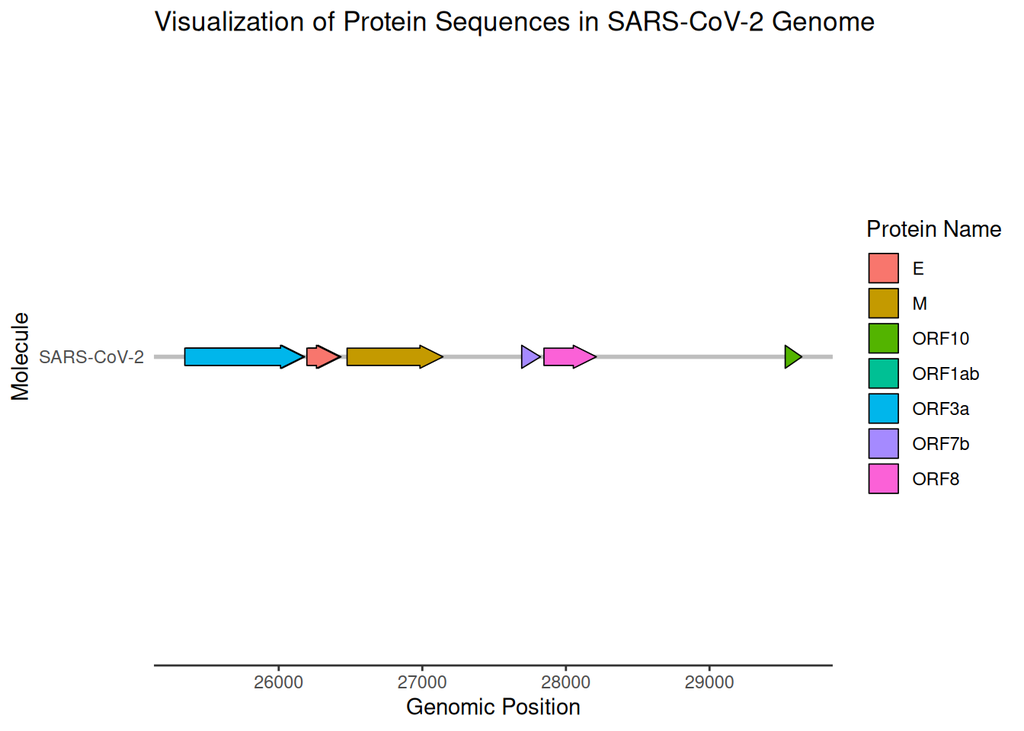

```r
# Plot using gggenes
library(gggenes)

# Create start and end positions for the protein sequences
covidData <- covidData |>
  mutate(start = as.numeric(str_extract(`Location`, "^[0-9]+")),
         end = as.numeric(str_extract(`Location`, "[0-9]+$")),
         strand = "+",  # Assume all sequences are on the positive strand
         molecule = "SARS-CoV-2")

# Sample data for visualization (for better visibility)
sampleData <- covidData |>
  sample_n(10)

# Plot using gggenes
ggplot(sampleData, aes(xmin = start, xmax = end, y = molecule, fill = `Protein Name`, label = `Protein Name`)) +
  geom_gene_arrow() +
  theme_genes() +
  labs(title = "Visualization of Protein Sequences in SARS-CoV-2 Genome", x = "Genomic Position", y = "Molecule")
```

### Dot plot for the number of unique Nuccore ids per protein name

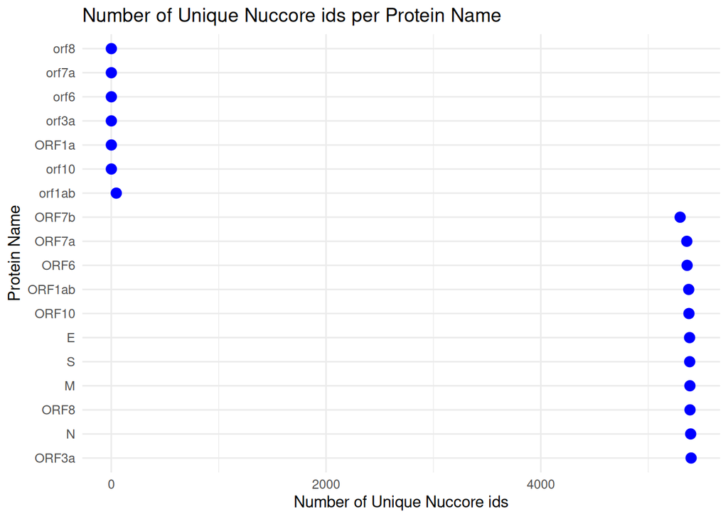

```r
ggplot(uniqueNuccId, aes(x = reorder(`Protein Name`, -uniqueNuccId), y = uniqueNuccId)) +
  geom_point(size = 3, color = "blue") +
  coord_flip() +
  labs(title = "Number of Unique Nuccore ids per Protein Name",
       x = "Protein Name",
       y = "Number of Unique Nuccore ids") +
  theme_minimal()
```

#### From this dot plot, we can visualise to which proteins, besides *ORF1ab*, researchers also gave attention during the pandemic.

# Interpretation / Conclusion

# References

[SARS-Cov-2 Genetics Dataset](https://www.kaggle.com/datasets/rtwillett/sarscov2-genetics/data?select=covid_cds.csv) *(Kaggle)*

[More information about the genome and proteins](https://www.ncbi.nlm.nih.gov/labs/virus/vssi/#/virus?SeqType_s=Nucleotide&VirusLineage_ss=taxid:2697049) *(NCBI)*